# REMMOA Analysis

Raphaëlle Momal

1 août 2018

# Data

Available data :

- counts $Y$,
- detections $N$
- covarites $X$.

## Covariates

Gathers information about the time( date, campaign), the transect (transect.label, sample.label, seg), the region (latitude, longitude, region.label, depth, DistCanyon, DistSeaMou, Dist200m, DistCot), the conditions (Effort, sea_state). To be checked : SlopePerce, Exoset, subjective, X and Y.

```r
str(X)
```

```
## 'data.frame':    2165 obs. of  20 variables:
##  $ date          : Date, format: "2014-11-12" "2014-11-12" ...
##  $ CAMPAIGN      : chr  "FR-N_C" "FR-N_C" "FR-N_C" "FR-N_C" ...
##  $ Transect.Label: chr  "O1/101" "O1/101" "O1/101" "O1/101" ...
##  $ Sample.Label  : int  1 1 2 2 2 4 5 5 5 6 ...
##  $ Seg           : int  2 3 7 8 10 12 13 14 15 16 ...
##  $ Effort        : num  10.6 10.6 10.8 10.8 10.8 ...
##  $ X             : num  392908 382305 339572 328754 307118 ...
##  $ Y             : num  8040158 8039874 8039025 8038932 8038747 ...
##  $ longitude     : num  164 164 163 163 163 ...
##  $ latitude      : num  -17.7 -17.7 -17.7 -17.7 -17.7 ...
##  $ Region.Label  : chr  "N_C_O1" "N_C_O1" "N_C_O1" "N_C_O1" ...
##  $ SEA_STATE     : num  3 3 2 2 2 2 3 3 3 3 ...
##  $ SUBJECTIVE    : chr  "GG" "GG" "GG" "GG" ...
##  $ Depth         : num  1406 3105 3913 3833 3441 ...
##  $ DistCanyon    : num  66611 62032 12166 11180 15556 ...
##  $ DistSeaMou    : num  0 0 23000 36497 65000 ...
##  $ Dist200m      : num  77820 83409 42544 33734 19000 ...
##  $ DistCot       : num  141993 128888 77389 66641 49041 ...
##  $ SlopePerce    : num  0.387 1.395 0.173 0.185 0.4 ...
##  $ Exocet        : num  NA NA NA NA NA NA NA NA NA NA ...
```

## Detection matrix

**A lot of zeros** .

```r
N<-as_tibble(N)
N
```

```
## # A tibble: 2,165 x 32
##    SMADEL BIGDEL SMAGLO BIGGLO BALSPP PHYMAC KOGIA ZIPHIUS DUGONG CHESPP
##  *  <dbl>  <dbl>  <dbl>  <dbl>  <dbl>  <dbl> <dbl>   <dbl>  <dbl>  <dbl>
##  1      0      0      0      0      0      0     0       0      0      0
##  2      0      0      0      0      0      0     0       0      0      0
##  3      0      0      0      0      0      0     0       0      0      0
##  4      0      0      0      0      0      0     0       0      0      0
##  5      0      0      0      0      0      0     0       0      0      0
##  6      0      0      0      0      0      0     0       1      0      0
##  7      0      0      0      0      0      0     0       0      0      0
##  8      0      0      0      0      0      0     0       0      0      0
##  9      0      0      0      0      0      0     0       0      0      0
## 10      0      0      0      2      0      0     0       0      0      0
## # ... with 2,155 more rows, and 22 more variables: RHITYP <dbl>,
## #   MARTEAU <dbl>, SHARKS <dbl>, DAURADE <dbl>, THON <dbl>,
## #   BILLFISH <dbl>, MANBIR <dbl>, MOBSPP <dbl>, DASSPP <dbl>,
## #   AETNAR <dbl>, RAIESP <dbl>, PHAETON <dbl>, GRETER <dbl>, BROTER <dbl>,
## #   GREPET <dbl>, BROPET <dbl>, LARNOV <dbl>, ANOSPP <dbl>, GYGALB <dbl>,
## #   FREGATE <dbl>, OCEANITE <dbl>, FOUS <dbl>
```

```r
apply(N, 2, sum)
```

```
##   SMADEL   BIGDEL   SMAGLO   BIGGLO   BALSPP   PHYMAC    KOGIA  ZIPHIUS
##       22       39       15       46       10       16       19       41
##   DUGONG   CHESPP   RHITYP  MARTEAU   SHARKS  DAURADE     THON BILLFISH
##       21      187       12       32      101      121       17       35
##   MANBIR   MOBSPP   DASSPP   AETNAR   RAIESP  PHAETON   GRETER   BROTER
##       29       22       35       81       31      245      318      659
##   GREPET   BROPET   LARNOV   ANOSPP   GYGALB  FREGATE OCEANITE     FOUS
##      725     3360        8      372      156       52       14      421
```

## Counts matrix

```r
Y<-as_tibble(Y)
Y
```

```
## # A tibble: 2,165 x 32
##    SMADEL BIGDEL SMAGLO BIGGLO BALSPP PHYMAC KOGIA ZIPHIUS DUGONG CHESPP
##  *  <dbl>  <dbl>  <dbl>  <dbl>  <dbl>  <dbl> <dbl>   <dbl>  <dbl>  <dbl>
##  1      0      0      0      0      0      0     0       0      0      0
##  2      0      0      0      0      0      0     0       0      0      0
##  3      0      0      0      0      0      0     0       0      0      0
##  4      0      0      0      0      0      0     0       0      0      0
##  5      0      0      0      0      0      0     0       0      0      0
##  6      0      0      0      0      0      0     0       1      0      0
##  7      0      0      0      0      0      0     0       0      0      0
##  8      0      0      0      0      0      0     0       0      0      0
##  9      0      0      0      0      0      0     0       0      0      0
## 10      0      0      0      3      0      0     0       0      0      0
## # ... with 2,155 more rows, and 22 more variables: RHITYP <dbl>,
## #   MARTEAU <dbl>, SHARKS <dbl>, DAURADE <dbl>, THON <dbl>,
## #   BILLFISH <dbl>, MANBIR <dbl>, MOBSPP <dbl>, DASSPP <dbl>,
## #   AETNAR <dbl>, RAIESP <dbl>, PHAETON <dbl>, GRETER <dbl>, BROTER <dbl>,
## #   GREPET <dbl>, BROPET <dbl>, LARNOV <dbl>, ANOSPP <dbl>, GYGALB <dbl>,
## #   FREGATE <dbl>, OCEANITE <dbl>, FOUS <dbl>
```

```r
apply(Y, 2, sum)
```

```
##   SMADEL   BIGDEL   SMAGLO   BIGGLO   BALSPP   PHYMAC    KOGIA  ZIPHIUS
##      437      448      587      236       15       33       26       91
##   DUGONG   CHESPP   RHITYP  MARTEAU   SHARKS  DAURADE     THON BILLFISH
##       25      203       12       32      156      169      851       60
##   MANBIR   MOBSPP   DASSPP   AETNAR   RAIESP  PHAETON   GRETER   BROTER
##       37       28       53      109       40      282     1481     2615
##   GREPET   BROPET   LARNOV   ANOSPP   GYGALB  FREGATE OCEANITE     FOUS
##      931    10879       60     1728      237       69       14      992
```

## Species

32 observed species/groups. Aquatic species:

- SMADEL/BIGDEL : petit dauphin indéterminé (BIGDEL : big ?)
- SMAGLO/BIGGLO
- BALSPP : Baleinoptéridé indéterminé
- PHYMAC : Cachalot
- KOGIA
- ZIPHIUS :baleine à bec de Cuvier/ ZIPCAV
- DUGONG : Dugong / DUGDUG
- CHESPP :Tortue à écailles
- RHITYP : requin baleine
- MARTEAU :Requin marteau/ SPHSPP
- SHARKS : requin indeterminés (SHARK)
- DAURADE : Daurade coryphène/ CORHIP
- THON : Thons, Bonites/ THUSPP
- BILLFISH
- MANBIR : raie manta
- MOBSPP : diable de mer
- DASSPP : raie pastenague
- AETNAR : raie léopard
- RAIESP
- PHAETON

Birds:

- GRETER : sternes grises
- BROTER : sternes brunes
- GREPET : pétrels gris
- BROPET : pétrels et puffins bruns
- LARNOV : mouette argentée
- ANOSPP : noddis bruns
- GYGALB : gygis blanches
- FREGATE
- FOUS : Fou indéterminé/ SULSPP

# Graphical visualizations

Global co-occurances per date (not transect) : 1 if detected on a day. (in $N$, possibility of several detections per transect).

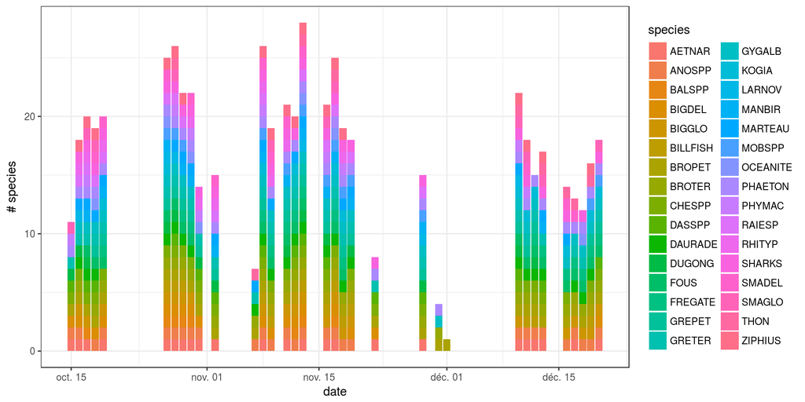

Per transect : 1 if detected on the transect.

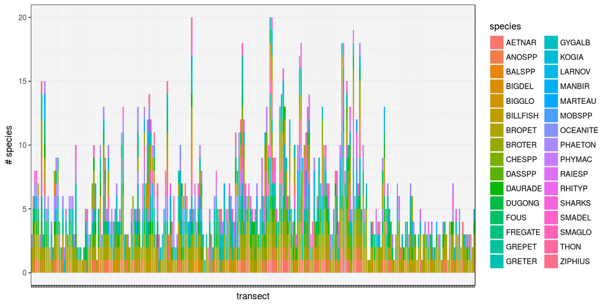

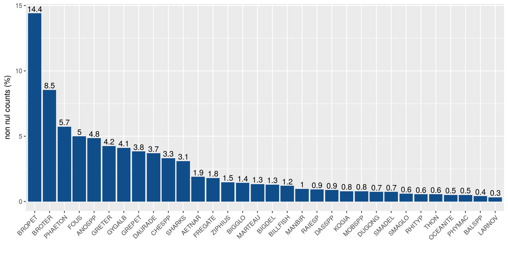

Non nul counts vary largely between species.

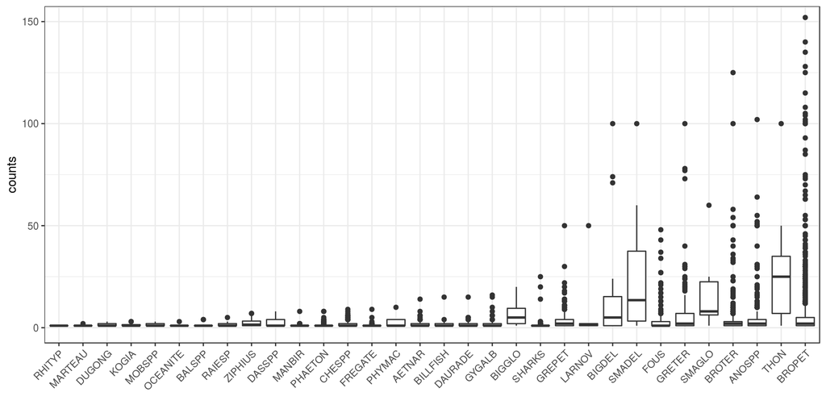